# Question 3

Aaron Quach

March 11, 2019

## Question 3 Analysis

### Which departments at each of these schools offer classes that have relatively high class GPAs and low GPAs?

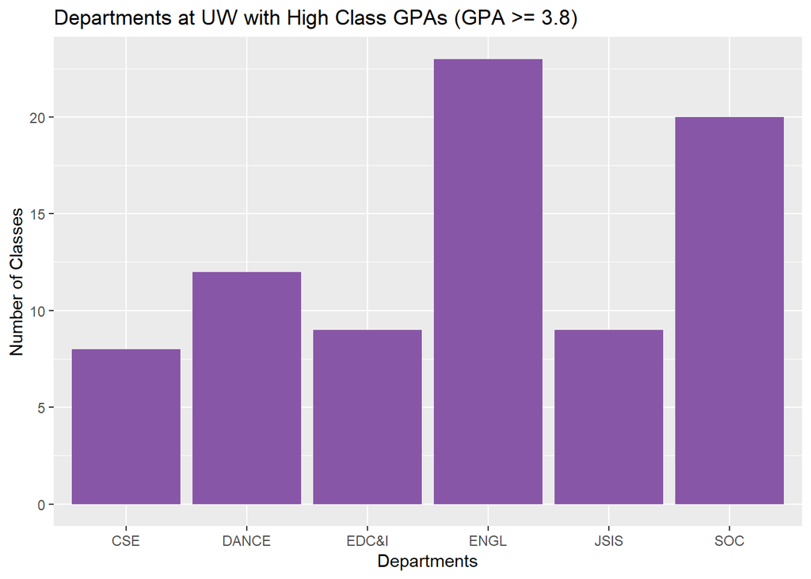

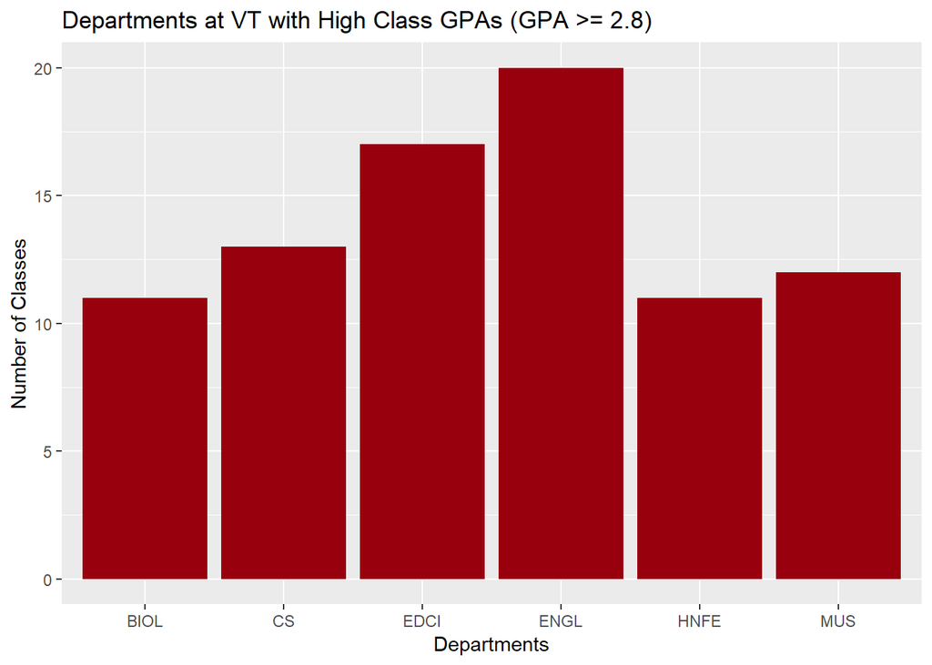

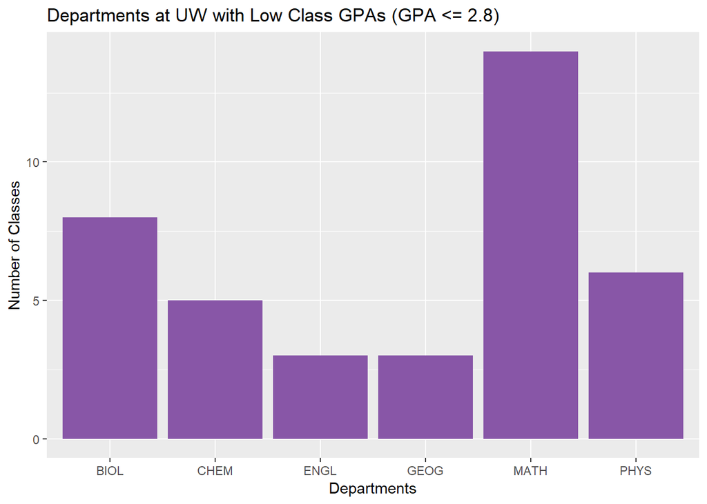

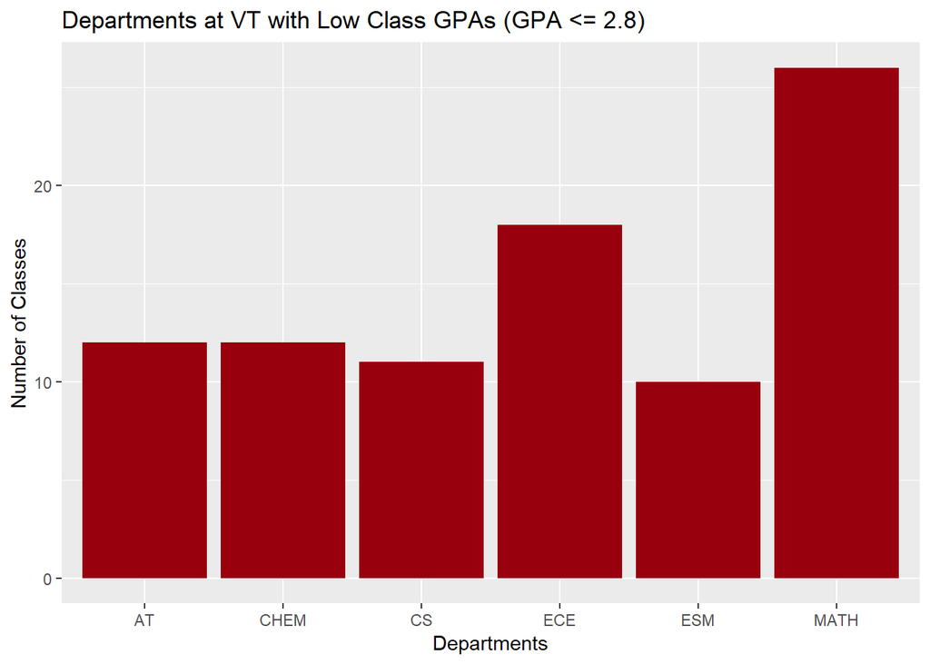

The first graph displays the top 6 departments at the at the University of Washington where a number of classes in each of these departments have an average GPA at or above a 3.8. From this graph the English department and Sociology departments have the most number of classes with 20 or more classes where students got high averages.

The third graph shows the top 6 departments at the University of Washington where the number of classes in each of these departments have an average GPA at or below a 2.8. In this graph, Math has the most amount of classes at 14 while the second highest is the Biology department which has 8 classes with a low average GPA.

The fourth graph shows the top 6 departments at Virgina Tech where the number of classes in each of these departments have an average GPa at or below a 2.8. In this graph the Math department and Electrical Computer Engineer department have the most amount of classes which has similarities to the UW data as the Math department also had the highest number of classes with low GPAs.